# Predicting Excessive Enforcement Patterns in Police Behavior After Vehicles Stops in New York

Model Selection and Evaluation - LASSO 4-Wheels

Gianmaria Pizzo

These `.Rmd` files represent the project submission for the course [Statistical Inference and Learning](https://www.unive.it/data/course/521944) by Professor [Cristiano Varin](https://www.unive.it/data/people/5592728) at [Ca’ Foscari University of Venice](https://www.unive.it/) for the year 2025/2026.

# 0) Environment

## 0.1) Packages

```r
requirements <- c(
  "scales", "stringr", "dplyr", "tidyr", "viridis",
  "ggplot2", "patchwork", "pROC", "kableExtra", "glmnet"
)
```

The list only contains packages actually used in this notebook. Now, the loading of all packages should be immediate.

## 0.2) Functions

Here we define the helper functions used throughout model selection and evaluation, kept in one place for reuse across every model fitted below.

### 0.2.1) Data-Split Diagnostics

```r
# ==============================================================================
# 1. Train / Test Split Diagnostics
# ==============================================================================

#' @title Check Train/Test Level Proportions
#'
#' @description Tabulates one variable's level proportions separately in
#' `train` and `test` and reports the discrepancy in percentage points. Used
#' to verify that the stratified split preserved the marginal distribution of
#' key covariates.
#'
#' @param var The column name (present in both `train` and `test`) to tabulate.
#' @param label Human-readable label for the variable, stored in the output.
#'
#' @return A tibble with columns variable, level, train, test, diff_ppt.
check_prop <- function(var, label) {
  # Compute the relative frequency of each level in the training set
  tr <- prop.table(table(train[[var]]))
  # Compute the relative frequency of each level in the test set
  te <- prop.table(table(test[[var]]))
  # Create a summary table comparing train and test proportions
  tibble(
    # Variable levels
    level = names(tr),
    # Proportion in training set
    train = as.numeric(tr),
    # Proportion in test set
    test = as.numeric(te),
    # Difference in % between test and training proportions
    diff_ppt = round((as.numeric(te) - as.numeric(tr)) * 100, 2)
  ) %>%
    # Add descriptive variable name
    mutate(variable = label) %>%
    # Move variable name to first column
    relocate(variable)
}
```

### 0.2.2) Threshold and Confusion-Matrix Helpers

```r
# ==============================================================================
# 2. Threshold Selection and Confusion-Matrix Helpers
# ==============================================================================

#' @title Find the Youden-Optimal Classification Threshold
#'
#' @description Finds the probability threshold on an ROC curve that
#' maximises Youden's J statistic (sensitivity + specificity − 1), used
#' throughout as the single decision threshold for turning predicted
#' probabilities into classes.
#'
#' @param roc_obj A pROC "roc" object, as returned by pROC::roc().
#'
#' @return A numeric scalar, the optimal threshold on the probability scale.
best_thresh <- function(roc_obj) {
  pROC::coords(
    roc_obj, "best", ret = "threshold",
    best.method = "youden", quiet = TRUE
  )$threshold
}


#' @title Tally a Confusion Matrix
#'
#' @description Cross-tabulates actual vs predicted binary class labels.
#'
#' @param actual Integer/numeric vector of 0/1 true labels.
#' @param predicted Integer/numeric vector of 0/1 predicted labels.
#'
#' @return A tibble with columns Actual, Predicted, n (one row per non-empty cell).
conf_tib <- function(actual, predicted) {
  tibble(
    Actual = factor(actual, levels = c(0, 1)),
    Predicted = factor(predicted, levels = c(0, 1))
  ) %>%
    count(Actual, Predicted)
}


#' @title Plot a Confusion-Matrix Heatmap
#'
#' @description Renders conf_tib() output as a 2x2 tile plot with cell counts.
#'
#' @param actual Integer/numeric vector of 0/1 true labels.
#' @param predicted Integer/numeric vector of 0/1 predicted labels.
#' @param title Main title of the plot.
#'
#' @return A ggplot2 object.
plot_cm <- function(actual, predicted, title = "Confusion Matrix") {
  conf_tib(actual, predicted) %>%
    ggplot(aes(Predicted, Actual, fill = n)) +
    geom_tile(colour = "white") +
    geom_text(aes(label = scales::comma(n)), size = 5.5, fontface = "bold") +
    scale_fill_gradient(low = "#e8f4f8", high = "#2c7bb6", guide = "none") +
    scale_x_discrete(labels = c("0" = "No arrest", "1" = "Arrest")) +
    scale_y_discrete(labels = c("0" = "No arrest", "1" = "Arrest")) +
    labs(title = title, x = "Predicted", y = "Actual") +
    theme_minimal(base_size = 12) +
    theme(panel.grid = element_blank())
}


#' @title Compute Threshold-Dependent Classification Metrics
#'
#' @description Computes sensitivity, specificity, balanced accuracy, PPV,
#' and NPV for a fixed set of hard class predictions against the true labels.
#'
#' @param actual Integer/numeric vector of 0/1 true labels.
#' @param predicted Integer/numeric vector of 0/1 predicted labels.
#' @param pos Value in `actual`/`predicted` denoting the positive class.
#'
#' @return A named list with sensitivity, specificity, balanced_acc, ppv, npv.
class_metrics <- function(actual, predicted, pos = 1) {
  tp <- as.numeric(sum(actual == pos & predicted == pos))
  tn <- as.numeric(sum(actual != pos & predicted != pos))
  fp <- as.numeric(sum(actual != pos & predicted == pos))
  fn <- as.numeric(sum(actual == pos & predicted != pos))
  sens <- tp / (tp + fn)
  spec <- tn / (tn + fp)
  list(
    sensitivity = sens,
    specificity = spec,
    balanced_acc = (sens + spec) / 2,
    ppv = tp / (tp + fp),
    npv = tn / (tn + fn)
  )
}


# ==============================================================================
# 3. Probability-Based Evaluation Metrics
# ==============================================================================

#' @title Compute the Full Evaluation-Metrics Tibble for One Model
#'
#' @description Given predicted probabilities and true labels, computes
#' threshold-free metrics (AUC, PR-AUC, log-loss, Brier score) plus
#' threshold-dependent metrics at the Youden-optimal cut-off (sensitivity,
#' specificity, precision, F1, MCC, balanced accuracy). Returns one row per
#' call, so results from multiple models can be row-bound into a comparison
#' table.
#'
#' @param actual Integer/numeric vector of 0/1 true labels.
#' @param prob Numeric vector of predicted P(arrested = 1), same length as `actual`.
#' @param thr Classification threshold selected externally (on the training set),
#' applied here rather than recomputed from `actual`/`prob` to avoid leaking test labels.
#' @param model_name Label stored in the Model column.
#'
#' @return A one-row tibble of rounded metrics (see column names in the body).
compute_metrics <- function(actual, prob, thr, model_name = "Model") {
  valid <- !is.na(actual) & !is.na(prob)
  actual <- actual[valid]
  prob <- prob[valid]

  roc_obj <- pROC::roc(actual, prob, quiet = TRUE)
  auc_val <- as.numeric(pROC::auc(roc_obj))
  pred_cl <- as.integer(prob >= thr)

  # Confusion Matrix Metrics
  tp <- as.numeric(sum(actual == 1 & pred_cl == 1))
  tn <- as.numeric(sum(actual == 0 & pred_cl == 0))
  fp <- as.numeric(sum(actual == 0 & pred_cl == 1))
  fn <- as.numeric(sum(actual == 1 & pred_cl == 0))

  # Confusion Matrix Derived Metrics
  sens <- (
    if ((tp+fn) == 0) NA_real_
    else tp / (tp+fn)
  )
  spec <- (
    if ((tn+fp) == 0) NA_real_
    else tn / (tn+fp)
  )
  prec <- (
    if ((tp+fp) == 0) NA_real_
    else tp / (tp+fp)
  )
  f1 <- (
    if (is.na(prec) || is.na(sens) || (prec+sens) == 0) NA_real_
    else 2 * prec * sens / (prec + sens)
  )

  # MCC
  mcc_den <- sqrt(
    as.numeric(tp+fp) * as.numeric(tp+fn) *
    as.numeric(tn+fp) * as.numeric(tn+fn)
  )
  mcc_val <- (
    if (mcc_den == 0) NA_real_
    else (tp*tn - fp*fn) / mcc_den
  )

  # Logloss
  eps <- 1e-15
  logloss <- -mean(
    actual * log(pmax(prob, eps)) +
    (1-actual) * log(pmax(1-prob, eps))
  )

  # Brier Score
  brier <- mean((prob - actual)^2)

  # PR-AUC via trapezoid rule over pROC coords (pROC has no built-in PR-AUC)
  pr_raw <- pROC::coords(
    roc_obj, "all", ret = c("sensitivity", "precision"),
    transpose = FALSE, drop = FALSE
  )

  names(pr_raw)[names(pr_raw) == "sensitivity"] <- "recall"

  pr_raw <- pr_raw %>%
    filter(!is.nan(precision), !is.na(precision), !is.nan(recall)) %>%
    arrange(recall)

  pr_auc_val <- if (nrow(pr_raw) >= 2)
    sum(diff(pr_raw$recall) * (head(pr_raw$precision, -1) + tail(pr_raw$precision, -1)) / 2)
  else NA_real_

  # Print Metrics
  tibble(
    Model = model_name,
    AUC = round(auc_val, 4),
    PR_AUC = round(pr_auc_val, 4),
    Log_Loss = round(logloss, 4),
    Brier = round(brier, 4),
    Threshold = round(thr, 4),
    Sensitivity = round(sens, 3),
    Specificity = round(spec, 3),
    Precision = round(prec, 3),
    F1 = round(f1, 3),
    MCC = round(mcc_val, 3),
    Bal_Acc = round(
      if (!is.na(sens) && !is.na(spec)) (sens+spec)/2
      else NA_real_, 3
    )
  )
}
```

### 0.2.3) Model Evaluation Plot Functions

```r
# ==============================================================================
# 4. Plots for Single-Model Evaluation
# ==============================================================================

#' @title Plot the ROC Curve for a Single Model
#'
#' @description Plots sensitivity vs specificity across all thresholds, with
#' the AUC annotated on the panel.
#'
#' @param actual Integer/numeric vector of 0/1 true labels.
#' @param prob Numeric vector of predicted P(arrested = 1), same length as `actual`.
#' @param title Main title of the plot.
#'
#' @return A ggplot2 object.
plot_roc_single <- function(actual, prob, title = "ROC Curve") {
  roc_obj <- pROC::roc(actual, prob, quiet = TRUE)
  auc_lbl <- paste0("AUC = ", round(as.numeric(pROC::auc(roc_obj)), 4))
  pROC::ggroc(roc_obj, colour = "#2c7bb6", linewidth = 0.9) +
    geom_abline(slope = 1, intercept = 1, linetype = "dashed", colour = "grey60") +
    annotate("text", x = 0.25, y = 0.06, label = auc_lbl, colour = "#2c7bb6", size = 4) +
    labs(x = "Specificity", y = "Sensitivity", title = title) +
    theme_minimal(base_size = 11) + theme(panel.grid.minor = element_blank())
}
```

```r
#' @title Plot the Precision-Recall Curve for a Single Model
#'
#' @description Plots precision vs recall across all thresholds against the
#' no-skill baseline (the class prevalence), with PR-AUC annotated. More
#' informative than the ROC curve under the severe class imbalance here.
#'
#' @param actual Integer/numeric vector of 0/1 true labels.
#' @param prob Numeric vector of predicted P(arrested = 1), same length as `actual`.
#' @param title Main title of the plot.
#'
#' @return A ggplot2 object.
plot_pr_single <- function(actual, prob, title = "Precision-Recall Curve") {
  roc_obj <- pROC::roc(actual, prob, quiet = TRUE)
  pr_raw  <- pROC::coords(roc_obj, "all",
                           ret = c("sensitivity", "precision"),
                           transpose = FALSE, drop = FALSE)
  names(pr_raw)[names(pr_raw) == "sensitivity"] <- "recall"
  pr_df <- pr_raw %>%
    filter(!is.nan(precision), !is.na(precision)) %>% arrange(recall)

  # PR-AUC via trapezoid rule, same approach as in compute_metrics()
  pr_auc_lbl <- if (nrow(pr_df) >= 2) {
    v <- sum(diff(pr_df$recall) *
               (head(pr_df$precision,-1) + tail(pr_df$precision,-1)) / 2)
    paste0("PR-AUC = ", round(v, 4))
  } else "PR-AUC = NA"
  baseline <- mean(actual)
  ggplot(pr_df, aes(x = recall, y = precision)) +
    geom_line(colour = "#d73027", linewidth = 0.9) +
    geom_hline(yintercept = baseline, linetype = "dashed", colour = "grey55") +
    annotate("text", x = 0.02, y = baseline + 0.015,
             label = paste0("No-skill = ", round(baseline, 3)),
             colour = "grey40", size = 3.2, hjust = 0) +
    annotate("text", x = 0.55, y = 0.90, label = pr_auc_lbl,
             colour = "#d73027", size = 4) +
    scale_x_continuous(limits = c(0, 1)) + scale_y_continuous(limits = c(0, 1)) +
    labs(x = "Recall", y = "Precision", title = title) +
    theme_minimal(base_size = 11) + theme(panel.grid.minor = element_blank())
}
```

```r
#' @title Plot the Calibration (Reliability) Curve for a Single Model
#'
#' @description Bins predictions into `n_bins` equal-frequency groups and
#' plots mean predicted probability against observed positive rate per bin,
#' against the perfect-calibration diagonal.
#'
#' @param actual Integer/numeric vector of 0/1 true labels.
#' @param prob Numeric vector of predicted P(arrested = 1), same length as `actual`.
#' @param title Main title of the plot.
#' @param n_bins Number of quantile bins of `prob`.
#'
#' @return A ggplot2 object.
plot_calibration_single <- function(actual, prob, title = "Calibration Plot",
                                    n_bins = 10) {
  # Quantile breaks (not equal-width) so each bin has a comparable sample size
  # despite the predicted probabilities being heavily right-skewed
  brks  <- unique(quantile(prob, seq(0, 1, length.out = n_bins + 1), na.rm = TRUE))
  cal_df <- tibble(actual = actual, prob = prob) %>%
    mutate(bin = cut(prob, breaks = brks, include.lowest = TRUE)) %>%
    filter(!is.na(bin)) %>%
    group_by(bin) %>%
    summarise(mean_pred = mean(prob), mean_obs = mean(actual),
              n = n(), .groups = "drop")
  ggplot(cal_df, aes(x = mean_pred, y = mean_obs)) +
    geom_abline(slope = 1, intercept = 0, linetype = "dashed", colour = "grey55") +
    geom_line(colour = "#2c7bb6", linewidth = 0.8) +
    geom_point(aes(size = n), colour = "#2c7bb6", alpha = 0.85) +
    scale_size_continuous(name = "Count", range = c(2, 9)) +
    scale_x_continuous(labels = scales::percent_format(accuracy = 0.1)) +
    scale_y_continuous(labels = scales::percent_format(accuracy = 0.1)) +
    labs(x = "Mean predicted probability", y = "Observed positive rate",
         title = title,
         caption = "Size ∝ bin count.  Dashed = perfect calibration.") +
    theme_minimal(base_size = 11) +
    theme(legend.position = "bottom", panel.grid.minor = element_blank())
}
```

```r
#' @title Plot the Threshold-Sweep Metrics for a Single Model
#'
#' @description Plots sensitivity, specificity, precision, and F1 as
#' functions of the classification threshold, with the Youden-optimal
#' threshold marked.
#'
#' @param actual Integer/numeric vector of 0/1 true labels.
#' @param prob Numeric vector of predicted P(arrested = 1), same length as `actual`.
#' @param thr Classification threshold selected externally (on the training set).
#' @param title Main title of the plot.
#'
#' @return A ggplot2 object.
plot_threshold_single <- function(actual, prob, thr, title = "Threshold Analysis") {
  roc_obj  <- pROC::roc(actual, prob, quiet = TRUE)
  thr_data <- pROC::coords(roc_obj, "all",
                            ret = c("threshold","sensitivity","specificity","precision"),
                            transpose = FALSE, drop = FALSE) %>%
    filter(is.finite(threshold), threshold >= 0, threshold <= 1) %>%
    mutate(f1 = ifelse(!is.nan(precision) & (precision + sensitivity) > 0,
                       2 * precision * sensitivity / (precision + sensitivity), 0)) %>%
    pivot_longer(c(sensitivity, specificity, precision, f1),
                 names_to = "Metric", values_to = "Value") %>%
    mutate(Metric = recode(Metric,
      sensitivity = "Sensitivity", specificity = "Specificity",
      precision   = "Precision",   f1          = "F1 Score"))
  ggplot(thr_data, aes(x = threshold, y = Value, colour = Metric)) +
    geom_line(linewidth = 0.75, na.rm = TRUE) +
    geom_vline(xintercept = thr, linetype = "dashed",
               colour = "grey35", linewidth = 0.55) +
    annotate("text", x = thr, y = 0.04,
             label = paste0("Train-selected\n", round(thr, 3)),
             hjust = -0.08, size = 3, colour = "grey30") +
    scale_colour_viridis_d(option = "turbo", begin = 0.05, end = 0.92) +
    scale_y_continuous(limits = c(0, 1)) +
    labs(x = "Threshold", y = "Metric value", colour = NULL, title = title,
         caption = "Dashed: threshold selected on the training set") +
    theme_minimal(base_size = 11) +
    theme(legend.position = "bottom", panel.grid.minor = element_blank())
}
```

```r
#' @title Plot the 2x2 Evaluation Panel for a Single Model
#'
#' @description Composes plot_roc_single(), plot_pr_single(),
#' plot_calibration_single(), and plot_threshold_single() into one
#' (ROC | PR) / (Calibration | Threshold) patchwork layout.
#'
#' @param actual Integer/numeric vector of 0/1 true labels.
#' @param prob Numeric vector of predicted P(arrested = 1), same length as `actual`.
#' @param thr Classification threshold selected externally (on the training set).
#' @param model_name Prefixed to each sub-plot's title.
#'
#' @return A patchwork object (composed ggplot2 object).
eval_quad_plot <- function(actual, prob, thr, model_name) {
  p1 <- plot_roc_single(actual, prob,   paste(model_name, "— ROC"))
  p2 <- plot_pr_single(actual, prob,    paste(model_name, "— Precision-Recall"))
  p3 <- plot_calibration_single(actual, prob, paste(model_name, "— Calibration"))
  p4 <- plot_threshold_single(actual, prob, thr, paste(model_name, "— Threshold Analysis"))
  (p1 | p2) / (p3 | p4)
}
```

### 0.2.4) Model-Summary Helpers

```r
# ==============================================================================
# 5. Coefficient Extraction Helpers
# ==============================================================================

#' @title Extract Non-Zero LASSO Coefficients at a Given Lambda
#'
#' @description Extracts the coefficients selected by a cv.glmnet fit at a
#' named lambda (e.g. "lambda.min" or "lambda.1se"), drops the zeroed-out
#' coefficients, and adds the exponentiated odds ratio.
#'
#' @param cv_fit A fitted glmnet::cv.glmnet object.
#' @param s_name Lambda selector passed to coef(cv_fit, s = s_name), typically
#' "lambda.min" or "lambda.1se".
#'
#' @return A tibble with columns feature, estimate (log-odds), OR (odds ratio),
#' sorted by descending |estimate|.
extract_coefs <- function(cv_fit, s_name) {
  cf <- coef(cv_fit, s = s_name)
  tibble(
    feature  = rownames(cf)[-1],
    estimate = as.numeric(cf[-1])
  ) %>%
    filter(estimate != 0) %>%
    arrange(desc(abs(estimate))) %>%
    mutate(OR = round(exp(estimate), 3), estimate = round(estimate, 4))
}
```

# 1) Data Loading and Preparation

```r
vehstop <- read.csv("data/vehiclestops_4_wheels_final.csv")
```

## 1.1) Factor conversion and Reference Levels

We convert all categorical predictors to factors and set interpretable reference levels before any modelling step, ensuring consistency between all downstream model fits and cross-validation folds.

```r
# Ordered weekday levels (ISO order)
wday_levels <- c("Monday", "Tuesday", "Wednesday", "Thursday", "Friday", "Saturday", "Sunday")

# Ordered time bracket levels
tbkt_levels <- c(
  "Late night (0–3)",
  "Early morning (4–7)",
  "Morning commute (8–11)",
  "Midday (12–15)",
  "Afternoon/evening (16–19)",
  "Night (20–23)"
)

# Ordered age-bracket levels
abkt_levels <- c("Under 18", "18–24", "25–34", "35–44", "45–54", "55–64", "65+", "Unknown")

vehstop <- vehstop %>%
  mutate(
    year = factor(year),
    month = factor(month, levels = 1:12),
    weekday = factor(weekday, levels = wday_levels),
    hour = factor(hour, levels = 0:23),
    time_bracket = factor(time_bracket, levels = tbkt_levels),
    area = factor(area),
    boro = factor(boro),
    sex = factor(sex),
    ethnicity = factor(ethnicity),
    age_bracket = factor(age_bracket, levels = abkt_levels)
  )

# Reference levels chosen for interpretable contrasts
vehstop$sex <- relevel(vehstop$sex, ref = "M")
vehstop$ethnicity <- relevel(vehstop$ethnicity, ref = "White")
vehstop$weekday <- relevel(vehstop$weekday, ref = "Monday")
vehstop$time_bracket <- relevel(vehstop$time_bracket, ref = "Morning commute (8–11)")
vehstop$age_bracket <- relevel(vehstop$age_bracket, ref = "25–34")

rm(wday_levels, tbkt_levels, abkt_levels)
```

## 1.2) Stratified Train / Test Split

For the train/test split, a **stratified sampling approach** is used to ensure that the training and test sets have comparable distributions of the outcome variable (`arrested`) and relevant contextual variables.

This is particularly important because the target variable is imbalanced, with arrested cases representing only a small proportion of all observations. Rather than stratifying only on `arrested`, the code constructs a **joint stratification variable** from `arrested`, `area`, `sex`, `ethnicity`, and `hour` using `interaction()`. Thus, each observation is assigned to a stratum corresponding to a particular combination of these variables.

Formally, the strata can be represented as

$$S_i =
(\text{arrested}_i,\text{area}_i,\text{sex}_i,\text{ethnicity}_i,\text{hour}_i),$$

where $S_i$ denotes the stratum to which observation $i$ belongs. The objective is to sample approximately 80% of observations within each stratum for the training set and retain the remaining 20% for testing:

$$P(i \in \mathcal{D}_{train} \mid S_i=s)
\approx 0.8,
\qquad
P(i \in \mathcal{D}_{test} \mid S_i=s) \approx 0.2.$$

```r
set.seed(2026)

# Joint stratum key; drop = TRUE removes empty combinations
vehstop$.strat <- interaction(
  vehstop$arrested, vehstop$area, vehstop$sex, vehstop$ethnicity, vehstop$hour,
  drop = TRUE
)

train_rows <- vehstop %>%
  dplyr::mutate(.row = row_number()) %>%
  dplyr::group_by(.strat) %>%
  dplyr::slice_sample(prop = 0.8) %>%
  dplyr::pull(.row)

train <- vehstop[ train_rows, ] %>% dplyr::select(-.strat)
test  <- vehstop[-train_rows, ] %>% dplyr::select(-.strat)
vehstop <- vehstop %>% dplyr::select(-.strat)
```

In the code, `group_by(.strat) %>% slice_sample(prop = 0.8)` performs this within-stratum sampling, while the observations not selected for training form the test set. This approach aims to preserve not only the overall prevalence of the outcome,

$$P_{\text{train}}(\text{arrested}=1)
\approx P_{\text{test}}(\text{arrested}=1),$$

but also the composition of the data across geographic, demographic, and temporal characteristics. This is desirable because differences in these characteristics could otherwise introduce an unintended distributional difference between the training and test sets. The temporary `.strat` variable is removed after the split because it is used solely to define the sampling groups and is not intended to be used as a predictor in the subsequent modelling.

Finally, the verification code compares the empirical marginal distributions of `arrested`, `area`, `sex`, and `ethnicity` in the two datasets. For a variable $X$ and level $k$, the proportion in each dataset is calculated as

$$\hat{P}_{train}(X=k)
=
\frac{\sum_{i \in \mathcal{D}_{train}} \mathbb{I}(X_i=k)}
{|\mathcal{D}_{train}|},$$

and analogously for the test set. The difference is then reported in **percentage points**:

$$\Delta_k =
100\left[
\hat{P}_{test}(X=k)
-
\hat{P}_{train}(X=k)
\right].$$

Small values of $\Delta_k$ indicate that the corresponding characteristic is similarly represented in the two datasets. The final summary additionally compares the number of observations and the proportion of arrested cases in the training and test sets, providing a direct check that the intended approximately 80/20 split and the class distribution have been maintained.

```r
bind_rows(
  check_prop("arrested", "arrested"),
  check_prop("area", "area"),
  check_prop("sex", "sex"),
  check_prop("ethnicity", "ethnicity")
) %>%
  kbl(
    digits = 4,
    caption = "Proportion of each level in train vs test (diff in percentage points)",
    col.names = c("Variable", "Level", "Train", "Test", "Δ (ppt)")
  ) %>%
  kable_styling(bootstrap_options = c("striped", "hover", "condensed"), full_width = FALSE) %>%
  collapse_rows(columns = 1, valign = "top")
```

Proportion of each level in train vs test (diff in percentage points)

| Variable | Level | Train | Test | Δ (ppt) |
| --- | --- | --- | --- | --- |
| arrested | 0 | 0.9674 | 0.9658 | -0.16 |
|  | 1 | 0.0326 | 0.0342 | 0.16 |
| area | Bronx | 0.1769 | 0.1770 | 0.01 |
|  | Brooklyn | 0.2972 | 0.2968 | -0.04 |
|  | Manhattan | 0.1938 | 0.1938 | 0.00 |
|  | Queens | 0.2550 | 0.2549 | -0.02 |
|  | Staten Island | 0.0771 | 0.0776 | 0.05 |
| sex | M | 0.8098 | 0.8081 | -0.17 |
|  | F | 0.1841 | 0.1849 | 0.08 |
|  | U | 0.0060 | 0.0070 | 0.10 |
| ethnicity | White | 0.1988 | 0.1987 | -0.01 |
|  | Asian / Pacific Islander | 0.1260 | 0.1261 | 0.01 |
|  | Black | 0.3059 | 0.3053 | -0.06 |
|  | Hispanic | 0.2637 | 0.2633 | -0.04 |
|  | Other | 0.0157 | 0.0163 | 0.05 |
|  | Unknown | 0.0899 | 0.0903 | 0.04 |

```r
cat(sprintf(
  "Training set : %d rows  |  Arrested: %.2f%%\nTest set     : %d rows  |  Arrested: %.2f%%\n",
  nrow(train), 100 * mean(train$arrested),
  nrow(test),  100 * mean(test$arrested)
))
```

```
## Training set : 1715002 rows  |  Arrested: 3.26%
## Test set     : 430585 rows  |  Arrested: 3.42%
```

The maximum absolute discrepancy between the two sets is on the order of fractions of a percentage point, confirming that the stratification preserved the joint distribution of the target and the key covariates.

```r
# Remove vehstop for memory purposes
rm(vehstop)
```

# 5) LASSO

**Why did we choose this model?** Given the size of the dataset and the rarity of the target, a penalised logistic regression is a trivial choice:

- It scales linearly in $n$,
- It handles many correlated dummy-encoded predictors, and
- It performs feature selection (derived from the $\ell_1$ penalty).

**Modus Operandi:** In this section we fit a LASSO logistic regression on `arrested` using the reduced predictor set (see below), then we compare the model obtained at $\lambda_{\min}$ against the more parsimonious one at $\lambda_{\text{1se}}$.

## 5.1) Assumptions and Setup

**LASSO (Least Absolute Shrinkage and Selection Operator)** is a regularization method that extends logistic regression by adding a penalty on the absolute size of the model coefficients.

In binary classification, it is particularly useful when there are many potentially relevant predictors and we want to identify a smaller set of variables associated with the probability of the positive outcome.

For a binary target $Y \in \{0,1\}$, LASSO logistic regression models

$$P(Y=1\mid X)=\frac{1}{1+\exp(-\eta)},$$

where

$$\eta=\beta_0+\beta_1X_1+\cdots+\beta_pX_p$$

Instead of simply maximizing the logistic likelihood, LASSO minimizes the penalized negative log-likelihood:

$$\hat{\beta} = \arg\min_{\beta} \left\{
-\ell(\beta) + \lambda\sum_{j=1}^{p}|\beta_j| \right\}$$

Here, $\lambda \geq 0$ controls the strength of regularization.

> In other words, this model penalises the sum of absolute coefficient values ($\ell_1$ penalty), which shrinks small effects to exactly zero and performs implicit variable selection.

We had to exclude `age` as a predictor, since we had missing values that we labeled as `Unknown` in `age_bracket`. Therefore, this is the final formulation of the model

```r
f_final <- arrested ~ year + month + weekday + hour + boro + sex + ethnicity + age_bracket
```

### 5.1.1) Model Matrix

Unlike `glm()`, `glmnet()` does not accept a formula and factor predictors directly: it requires a numeric design matrix, so every categorical predictor must be dummy-encoded first via `model.matrix()` (see also section 1.1).

Then, the intercept column produced by `model.matrix()` is dropped (`[, -1]`) because `glmnet` fits its own unpenalised intercept internally.

Standardisation of the columns before penalisation is handled automatically by `glmnet` (`standardize = TRUE` is the default), so no manual scaling is needed here.

```r
mm_train <- model.frame(f_final, data = train, na.action = na.omit)
X_train <- model.matrix(f_final, data = mm_train)[, -1]
y_train <- mm_train$arrested

mm_test <- model.frame(f_final, data = test, na.action = na.omit)
X_test <- model.matrix(f_final, data = mm_test)[, -1]
y_test <- mm_test$arrested

cat("Training matrix:", nrow(X_train), "×", ncol(X_train), "\n")
```

```
## Training matrix: 1715002 × 63
```

```r
cat("Test matrix :", nrow(X_test),  "×", ncol(X_test),  "\n")
```

```
## Test matrix : 430585 × 63
```

## 5.2) Hyperparameter Tuning and Model Fit — Cross-Validated Lambda

The regularization parameter is typically selected using cross-validation. With an imbalanced binary outcome, it is important that the cross-validation folds preserve approximately the same proportion of positive cases. Unfortunately, we did not have enough time to create a more precise CV function to take into account proportions in between folds.

We optimise $\lambda$ by maximising cross-validated AUC (`type.measure = "auc"`), which is the appropriate metric for an imbalanced binary outcome. In fact, for a $3-5\%$ positive class, ROC-AUC is generally preferable to classification error, because the latter can be dominated by the majority class.

```r
set.seed(2026)
cv_lasso <- cv.glmnet(
  X_train, y_train,
  family = "binomial",
  alpha = 1,
  nfolds = 5,
  type.measure = "auc"
)

cat(sprintf(
  "λ.min  = %.6f  (CV AUC = %.4f, SE = %.6f)\nλ.1se  = %.6f  (CV AUC = %.4f, SE = %.6f)\n",
  cv_lasso$lambda.min,
  max(cv_lasso$cvm),
  cv_lasso$cvsd[cv_lasso$lambda == cv_lasso$lambda.min],
  cv_lasso$lambda.1se,
  cv_lasso$cvm[cv_lasso$lambda == cv_lasso$lambda.1se],
  cv_lasso$cvsd[cv_lasso$lambda == cv_lasso$lambda.1se]
))
```

```
## λ.min  = 0.000048  (CV AUC = 0.7524, SE = 0.001025)
## λ.1se  = 0.000256  (CV AUC = 0.7515, SE = 0.001057)
```

```r
coef_min <- extract_coefs(cv_lasso, "lambda.min")
coef_1se <- extract_coefs(cv_lasso, "lambda.1se")

cat("Non-zero coefficients at λ.min:", nrow(coef_min), "\n")
```

```
## Non-zero coefficients at λ.min: 63
```

```r
cat("Non-zero coefficients at λ.1se:", nrow(coef_1se), "\n")
```

```
## Non-zero coefficients at λ.1se: 50
```

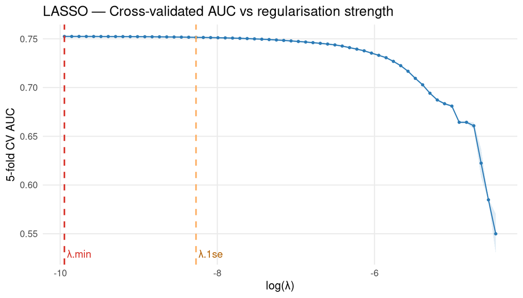

```r
# Replicate the cv.glmnet plot in ggplot2
cv_df <- tibble(
  log_lambda = log(cv_lasso$lambda),
  cvm = cv_lasso$cvm,
  cvup = cv_lasso$cvup,
  cvlo = cv_lasso$cvlo,
  nzero = cv_lasso$nzero,
  cvsd = cv_lasso$cvsd
)

ggplot(cv_df, aes(x = log_lambda, y = cvm)) +
  geom_ribbon(aes(ymin = cvlo, ymax = cvup), alpha = 0.15, fill = "#2c7bb6") +
  geom_line(colour = "#2c7bb6") +
  geom_point(size = 0.8, colour = "#2c7bb6") +
  geom_vline(xintercept = log(cv_lasso$lambda.min), linetype = "dashed",
             colour = "#d73027", linewidth = 0.7) +
  geom_vline(xintercept = log(cv_lasso$lambda.1se), linetype = "dashed",
             colour = "#fdae61", linewidth = 0.7) +
  annotate("text", x = log(cv_lasso$lambda.min), y = min(cv_df$cvlo),
           label = "λ.min", colour = "#d73027", hjust = -0.1, size = 3.5) +
  annotate("text", x = log(cv_lasso$lambda.1se), y = min(cv_df$cvlo),
           label = "λ.1se", colour = "#b36200", hjust = -0.1, size = 3.5) +
  labs(
    x     = "log(λ)",
    y     = "5-fold CV AUC",
    title = "LASSO — Cross-validated AUC vs regularisation strength"
  ) +
  theme_minimal(base_size = 11) +
  theme(panel.grid.minor = element_blank())
```

The curve indicates that predictive discrimination is highly stable across this range of regularisation strengths. The model does not need the additional complexity associated with very small values of $\lambda$ to maintain its cross-validated discrimination.

The right-hand side of the plot is also informative. As $\lambda$ becomes substantially larger, AUC initially declines gradually and then much more sharply. Eventually, too many useful coefficients are shrunk toward zero and discrimination deteriorates considerably.

### 5.2.1) Interpretation of the lambda’s cross-validation curve

At $\lambda_{\text{min}} = 0.000048$

- The model achieves the maximum cross-validated AUC: $\text{AUC} = 0.7524$
- And it retains **63** non-zero coefficients.

At $\lambda_{\text{1se}} = 0.000256$

- The model is much more strongly regularised as it retains only **50** non-zero coefficients,
- But its CV AUC decreases only slightly: $0.7524 \rightarrow 0.7515$

That’s a reduction of only $0.7524 - 0.7515 = 0.0009$ in AUC points at $\lambda_{\text{min}}$.

Meanwhile, the number of coefficients falls from 63 to 50:

$$\frac{63-50}{63} \cdot 100 \approx
20.6\%$$

So the 1-SE model “removes” (sets to 0) approximately one-fifth of the non-zero coefficients while changing CV-AUC by less than one-thousandth. This is an even stronger complexity-performance trade-off than in our other dataset.

The standard errors are:

$$SE_{\text{min}} = 0.001025 \,\,
\text{and} \,\, SE_{\text{1se}} = 0.001057$$
So the difference is smaller than either reported standard error. This reinforces the idea that there is no practically meaningful evidence that $\lambda_{\text{min}$ predicts better than $\lambda_{\text{1se}$.

**What does this say about the training?** The 1-SE model reduces the number of non-zero coefficients from 63 to 50, a reduction of approximately $21\%$, while reducing cross-validated AUC by only $0.0009$. The substantially stronger regularisation therefore achieves essentially the same estimated predictive discrimination with a considerably more parsimonious model.

## 5.3) Specific Analysis and Interpretation

### 5.3.1) Coefficient Path

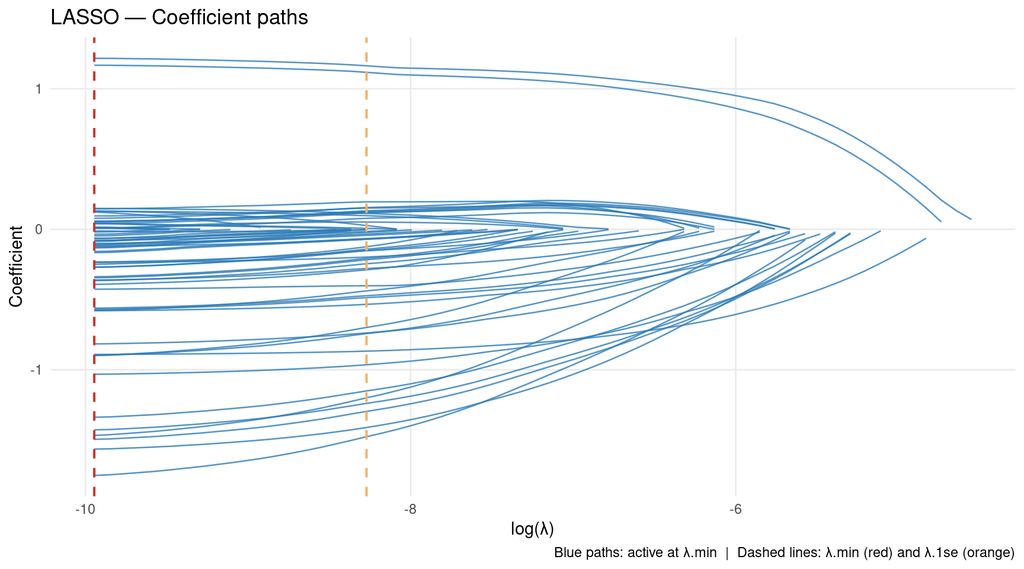

```r
# Tidy the full coefficient path
coef_path <- as.matrix(coef(cv_lasso$glmnet.fit))   # (p+1) × n_lambda
lambdas   <- cv_lasso$glmnet.fit$lambda

path_df <- as.data.frame(t(coef_path[-1, ])) %>%   # drop intercept row
  mutate(log_lambda = log(lambdas)) %>%
  pivot_longer(-log_lambda, names_to = "feature", values_to = "coef") %>%
  filter(coef != 0)

# Only label non-zero at lambda.min for clarity
active_min <- names(which(coef(cv_lasso, s = "lambda.min")[-1, 1] != 0))

ggplot(path_df, aes(x = log_lambda, y = coef, group = feature,
                    colour = feature %in% active_min)) +
  geom_line(linewidth = 0.45, alpha = 0.8) +
  geom_vline(xintercept = log(cv_lasso$lambda.min), linetype = "dashed",
             colour = "#d73027", linewidth = 0.7) +
  geom_vline(xintercept = log(cv_lasso$lambda.1se), linetype = "dashed",
             colour = "#fdae61", linewidth = 0.7) +
  scale_colour_manual(values = c("TRUE" = "#2c7bb6", "FALSE" = "grey70"),
                      guide  = "none") +
  labs(
    x       = "log(λ)",
    y       = "Coefficient",
    title   = "LASSO — Coefficient paths",
    caption = "Blue paths: active at λ.min  |  Dashed lines: λ.min (red) and λ.1se (orange)"
  ) +
  theme_minimal(base_size = 11) +
  theme(panel.grid.minor = element_blank())
```

What is visible here? Between the red and orange lines, the coefficient’s paths change very little. The larger positive and negative coefficients remain clearly separated from zero, although their magnitudes are reduced somewhat. At the same time, several of the smaller coefficients are pushed toward or exactly to zero. This suggests that the 13 coefficients set to 0 by moving from $\lambda_{\text{min}}$ to $\lambda_{\text{1se}}$ are predominantly coefficients with comparatively weak contributions under the penalised model.

**Some coefficients are much more resistant to shrinkage**, in particular, the two large positive paths at the top and several large negative paths at the bottom survive against a stronger regularisation. These predictors appear to contain more persistent predictive signal: the model retains them even when the penalty becomes considerably stronger (we will see them later).

There is also a visible difference from the coefficient-path plot for the previous dataset. Here, there seems to be a **smaller number of clearly dominant coefficients**, particularly the two large positive paths around $1.2$ and several negative paths around $-1$ to $-1.8$. Many of the remaining coefficients are concentrated much more closely around zero.

This supports using $\lambda_{\text{1se}}$ since our objective is a simpler, more interpretable model rather than squeezing out the absolute maximum CV AUC.

### 5.3.2) Non-Zero Coefficients ats λ.min

This table is useful for interpreting which variables LASSO retains and the direction/magnitude of their association with `arrested = 1`

```r
coef_min %>%
  kbl(
    caption   = "LASSO coefficients at λ.min (sorted by |estimate|)",
    col.names = c("Feature", "Log-odds", "Odds Ratio")
  ) %>%
  kable_styling(bootstrap_options = c("striped", "condensed"), full_width = FALSE)
```

LASSO coefficients at λ.min (sorted by |estimate|)

| Feature | Log-odds | Odds Ratio |
| --- | --- | --- |
| hour7 | -1.7520 | 0.173 |
| age_bracket65+ | -1.5645 | 0.209 |
| hour8 | -1.4947 | 0.224 |
| hour6 | -1.4670 | 0.231 |
| hour9 | -1.4275 | 0.240 |
| hour10 | -1.3375 | 0.262 |
| ethnicityBlack | 1.2171 | 3.377 |
| ethnicityHispanic | 1.1679 | 3.215 |
| age_bracket55–64 | -1.0316 | 0.356 |
| hour5 | -0.8984 | 0.407 |
| hour11 | -0.8966 | 0.408 |
| sexF | -0.8905 | 0.410 |
| age_bracketUnknown | -0.8158 | 0.442 |
| age_bracket45–54 | -0.5796 | 0.560 |
| hour12 | -0.5775 | 0.561 |
| boroManhattan (South) | -0.5695 | 0.566 |
| boroQueens (North) | -0.5610 | 0.571 |
| ethnicityUnknown | -0.4263 | 0.653 |
| ethnicityOther | -0.3924 | 0.675 |
| hour16 | -0.3646 | 0.694 |
| boroQueens (South) | -0.3612 | 0.697 |
| hour15 | -0.3448 | 0.708 |
| hour13 | -0.3379 | 0.713 |
| hour17 | -0.2696 | 0.764 |
| hour14 | -0.2692 | 0.764 |
| age_bracketUnder 18 | -0.2491 | 0.780 |
| age_bracket35–44 | -0.2357 | 0.790 |
| boroBrooklyn (North) | -0.2325 | 0.793 |
| month7 | -0.1658 | 0.847 |
| month8 | -0.1578 | 0.854 |
| year2024 | 0.1485 | 1.160 |
| hour3 | 0.1463 | 1.158 |
| month5 | -0.1322 | 0.876 |
| ethnicityAsian / Pacific Islander | 0.1307 | 1.140 |
| year2025 | 0.1291 | 1.138 |
| month9 | -0.1272 | 0.881 |
| sexU | 0.1227 | 1.131 |
| age_bracket18–24 | -0.1201 | 0.887 |
| hour18 | -0.1134 | 0.893 |
| month6 | -0.1066 | 0.899 |
| boroManhattan (North) | -0.1008 | 0.904 |
| hour2 | 0.0951 | 1.100 |
| month11 | -0.0861 | 0.918 |
| month10 | -0.0804 | 0.923 |
| boroStaten Island | -0.0799 | 0.923 |
| hour19 | 0.0785 | 1.082 |
| month4 | -0.0661 | 0.936 |
| boroBrooklyn (South) | -0.0634 | 0.939 |
| hour1 | 0.0590 | 1.061 |
| hour20 | 0.0540 | 1.055 |
| hour22 | 0.0532 | 1.055 |
| month2 | -0.0467 | 0.954 |
| weekdayWednesday | 0.0433 | 1.044 |
| hour21 | 0.0410 | 1.042 |
| weekdayTuesday | 0.0403 | 1.041 |
| month3 | -0.0353 | 0.965 |
| hour4 | -0.0192 | 0.981 |
| weekdayThursday | 0.0154 | 1.016 |
| weekdaySunday | -0.0122 | 0.988 |
| weekdaySaturday | 0.0110 | 1.011 |
| hour23 | 0.0087 | 1.009 |
| weekdayFriday | 0.0087 | 1.009 |
| month12 | 0.0077 | 1.008 |

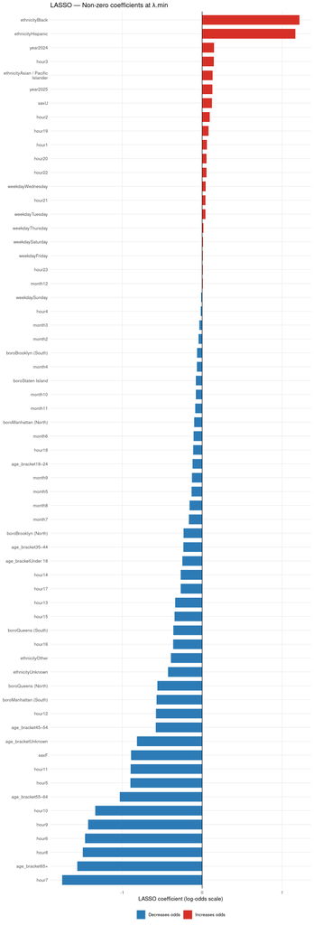

```r
coef_min %>%
  mutate(
    direction = ifelse(estimate > 0, "Increases odds", "Decreases odds"),
    feature   = stringr::str_wrap(feature, 30)
  ) %>%
  ggplot(aes(x = estimate, y = reorder(feature, estimate), fill = direction)) +
  geom_col(width = 0.7) +
  geom_vline(xintercept = 0, linewidth = 0.4) +
  scale_fill_manual(values = c("Increases odds" = "#d73027", "Decreases odds" = "#2c7bb6")) +
  labs(
    x     = "LASSO coefficient (log-odds scale)",
    y     = NULL,
    fill  = NULL,
    title = "LASSO — Non-zero coefficients at λ.min"
  ) +
  theme_minimal(base_size = 10) +
  theme(legend.position = "bottom", panel.grid.minor = element_blank())
```

#### 5.3.2.1) General Interpretation

At $\lambda_{\text{min}}$, LASSO retains 63 non-zero coefficients. The coefficient is on the log-odds scale:

$$\log\left(\frac{P(\text{arrested}=1)}{1-P(\text{arrested}=1)}\right) =
\beta_0+\sum_j\beta_jX_j.$$

The corresponding odds ratio is

$$OR_j=e^{\beta_j}.$$

Therefore:

- $\beta_j > 0$, $OR > 1$: higher estimated odds of `arrested = 1`.
- $\beta_j < 0$, $OR < 1$: lower estimated odds.
- $\beta_j \approx 0$, $OR \approx 1$: relatively little contribution after regularisation.

Note that, for categorical variables, each coefficient is relative to the omitted reference category.

> These odds ratios are derived from penalised coefficients and should be interpreted as predictive associations originating from the model. In fact, they do not represent unbiased inferential effect estimates.

#### 5.3.2.2) Specific Interpretation

The largest coefficients fall into three groups: **time of day, age, and ethnicity**.

Here too, `hour` appears to be an important predictor.

In particular let us look at `hour7`:

$$\beta_{\text{hour7}} = -1.75 \quad OR =
0.173$$

This means that, `hour7` is associated with circa $(1-0.173) \times 100 = 82.7\%$ lower estimated odds of arrest (relative to the reference hour), conditional on the other variables (fixed).

A similar pattern occurs across the whole “morning”:

$$\begin{aligned}
OR_{6} & = 0.231 \rightarrow 76.9\% \\
OR_{7} & = 0.173 \rightarrow 82.7\% \\
OR_{8} & = 0.224 \rightarrow 77.6\% \\
OR_{9} & = 0.240 \rightarrow 76\% \\
OR_{10} & = 0.262 \rightarrow 73.8\% \\
OR_{11} & = 0.408 \rightarrow 59.2\%
\end{aligned}$$

The important result is therefore not specifically that *7 AM* has a large coefficient, but that **a broad block of morning hours has substantially lower predicted arrest odds relative to the reference hour** (midnight). This temporal pattern then weakens later in the day and by hours 18–23, most coefficients are much closer to zero.

In the second place, `age` is particularly interesting in this dataset.

The largest age coefficient is:

$$\beta_{\text{65+}} = -1.565 \quad OR =
0.20$$

Conditional on the other predictors, the estimated odds for the 65+ category are therefore approximately **79% lower than for the reference age category**.

From the following

$$\begin{aligned}
OR_{55-64} & = 0.356 \rightarrow -64.4\% \\
OR_{45-54} & = 0.560 \rightarrow -44\% \\
OR_{35-44} & = 0.790 \rightarrow -21\% \\
OR_{18-24} & = 0.887 \rightarrow -11.3\%
\end{aligned}$$

there seems to be pattern whereby **older age categories receive progressively more negative coefficients** relative to the reference category.

Again, this is an **association with predicted arrest odds**, not evidence that age causally affects arrest.

Then, `ethnicity` has two of the largest positive coefficients. The two main coefficients that stand out are:

$$\begin{aligned}
\beta_{\text{Black}} = 1.217, \quad \text{OR}_{\text{Black}} = 3.377
\rightarrow (337.7 - 100) = +237.7 \% \\
\beta_{\text{Hispanic}} = 1.168, \quad \text{OR}_{\text{Hispanic}} =
3.215 \rightarrow (321.5 - 100) = +221.5 \% \\
\end{aligned}$$

Thus, relative to the reference ethnicity category (`White`) and conditional on the other model variables, the estimated odds of the observed arrest outcome are approximately **3.38 and 3.22 times as large**, respectively.

What can we say here? Black and Hispanic ethnicity categories exhibit some of the largest positive coefficients in the fitted LASSO model, **corresponding to substantially higher predicted odds of the observed arrest outcome relative to the reference ethnicity category after conditioning on the included covariates**.

Let us consider `sex` now - For `sexF`, we have $\beta= -0.891, \, OR = 0.410$. Therefore, relative to the reference sex category (male), female observations have approximately $1-0.410 = 0.590$ or **59% lower estimated odds of the observed arrest outcome**, conditional on the included predictors. - By contrast, $OR_{\text{sexU}} = 1.131 \rightarrow (113.1 - 100) = +13.1\%$ is much closer to one.

Geography contributes predictive information, although its coefficients are generally less extreme than the strongest temporal, age, and ethnicity coefficients.

- For example, $OR_{\text{Manhattan South}} = 0.566, \, OR_{\text{Queens North}}=0.571$. These indicate ($43.5\%$ and $42.9\%$ respectively) lower predicted arrest odds relative to the omitted geographic reference category.
- On the other hand $OR_{\text{Brooklyn South}}=0.939, \, OR_{\text{Staten Island}}=0.923$ are much closer to one and therefore have comparatively small penalised coefficients.

For what concerns the `month`, `weekday` and `year`, we have clearly some of the weakest effects

Finally, we can see a clear difference in the two datasets by just checking some of the following aspects:

- Previously, we had approximately $OR_{\text{Black}}=1.45, \, OR_{\text{Hispanic}}=1.78$, but here we have $OR_{\text{Black}}=3.38, \, OR_{\text{Hispanic}}=3.22$
- `Under 18` previously had a positive coefficient, whereas here $\beta_{\text{Under 18}}=-0.249.$

This shows that the estimated coefficient structure is not necessarily invariant across datasets.

#### 5.3.2.3) Important Remark

Because only $3-5\%$ of observations are arrests, **some combinations of categorical levels may contain very few positive observations**. Large coefficients (especially for relatively uncommon categories) should therefore not automatically be interpreted as strong underlying effects. In fact, LASSO reduces this instability through shrinkage, but it does not eliminate the underlying data sparsity.

### 5.3.3) Non-Zero Coefficients ats λ.1se

If the same major predictors remain at $\lambda_{\text{1se}}$, while mostly small coefficients disappear, that would provide strong evidence that our main predictive relationships are robust to regularisation.

```r
coef_1se %>%
  kbl(
    caption   = "LASSO coefficients at λ.1se (sorted by |estimate|)",
    col.names = c("Feature", "Log-odds", "Odds Ratio")
  ) %>%
  kable_styling(bootstrap_options = c("striped", "condensed"), full_width = FALSE)
```

LASSO coefficients at λ.1se (sorted by |estimate|)

| Feature | Log-odds | Odds Ratio |
| --- | --- | --- |
| hour7 | -1.4763 | 0.228 |
| age_bracket65+ | -1.4107 | 0.244 |
| hour8 | -1.2962 | 0.274 |
| hour9 | -1.2388 | 0.290 |
| hour6 | -1.1996 | 0.301 |
| ethnicityBlack | 1.1638 | 3.202 |
| hour10 | -1.1504 | 0.317 |
| ethnicityHispanic | 1.1174 | 3.057 |
| age_bracket55–64 | -0.9642 | 0.381 |
| sexF | -0.8674 | 0.420 |
| hour11 | -0.7423 | 0.476 |
| age_bracketUnknown | -0.7378 | 0.478 |
| hour5 | -0.6986 | 0.497 |
| age_bracket45–54 | -0.5342 | 0.586 |
| boroManhattan (South) | -0.4863 | 0.615 |
| boroQueens (North) | -0.4727 | 0.623 |
| hour12 | -0.4383 | 0.645 |
| ethnicityUnknown | -0.4019 | 0.669 |
| ethnicityOther | -0.2884 | 0.749 |
| boroQueens (South) | -0.2792 | 0.756 |
| hour16 | -0.2450 | 0.783 |
| hour15 | -0.2168 | 0.805 |
| hour13 | -0.2065 | 0.813 |
| age_bracket35–44 | -0.1975 | 0.821 |
| hour3 | 0.1954 | 1.216 |
| hour19 | 0.1549 | 1.168 |
| boroBrooklyn (North) | -0.1528 | 0.858 |
| hour2 | 0.1511 | 1.163 |
| hour17 | -0.1506 | 0.860 |
| hour14 | -0.1411 | 0.868 |
| hour20 | 0.1317 | 1.141 |
| hour22 | 0.1270 | 1.135 |
| age_bracketUnder 18 | -0.1242 | 0.883 |
| hour1 | 0.1206 | 1.128 |
| hour21 | 0.1172 | 1.124 |
| year2024 | 0.1131 | 1.120 |
| year2025 | 0.0969 | 1.102 |
| hour23 | 0.0784 | 1.082 |
| month7 | -0.0711 | 0.931 |
| age_bracket18–24 | -0.0697 | 0.933 |
| month8 | -0.0657 | 0.936 |
| month12 | 0.0517 | 1.053 |
| month5 | -0.0429 | 0.958 |
| month9 | -0.0341 | 0.966 |
| ethnicityAsian / Pacific Islander | 0.0270 | 1.027 |
| boroManhattan (North) | -0.0220 | 0.978 |
| month6 | -0.0153 | 0.985 |
| weekdayWednesday | 0.0069 | 1.007 |
| boroStaten Island | -0.0028 | 0.997 |
| weekdaySunday | -0.0025 | 0.998 |

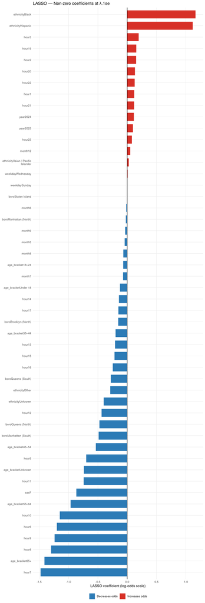

```r
coef_1se %>%
  mutate(
    direction = ifelse(estimate > 0, "Increases odds", "Decreases odds"),
    feature   = stringr::str_wrap(feature, 30)
  ) %>%
  ggplot(aes(x = estimate, y = reorder(feature, estimate), fill = direction)) +
  geom_col(width = 0.7) +
  geom_vline(xintercept = 0, linewidth = 0.4) +
  scale_fill_manual(values = c("Increases odds" = "#d73027", "Decreases odds" = "#2c7bb6")) +
  labs(
    x     = "LASSO coefficient (log-odds scale)",
    y     = NULL,
    fill  = NULL,
    title = "LASSO — Non-zero coefficients at λ.1se"
  ) +
  theme_minimal(base_size = 10) +
  theme(legend.position = "bottom", panel.grid.minor = element_blank())
```

This confirms the interpretation from the coefficient paths quite well. Moving from $\lambda_{\min}$ to $\lambda_{1se}$ sets to 0, **13 coefficients**, but the structure of the model remains largely unchanged.

#### 5.3.3.1) The strongest coefficients remain stable

For the main predictors, the signs and approximate ranking are highly consistent:

| Feature | $\beta_{\min}$ | $\beta_{1se}$ | OR $\lambda_{\min}$ | OR $\lambda_{1se}$ |
| --- | --- | --- | --- | --- |
| `hour7` | -1.752 | -1.476 | 0.173 | 0.228 |
| `age 65+` | -1.565 | -1.411 | 0.209 | 0.244 |
| `hour8` | -1.495 | -1.296 | 0.224 | 0.274 |
| `hour9` | -1.428 | -1.239 | 0.240 | 0.290 |
| `hour6` | -1.467 | -1.200 | 0.231 | 0.301 |
| `Black` | +1.217 | +1.164 | 3.377 | 3.202 |
| `Hispanic` | +1.168 | +1.117 | 3.215 | 3.057 |
| `age 55–64` | -1.032 | -0.964 | 0.356 | 0.381 |
| `sexF` | -0.891 | -0.867 | 0.410 | 0.420 |

This is a useful result because they remain strong under the more aggressive 1-SE regularisation. In particular, the Black, Hispanic and Female Sex coefficients are remarkably stable.

Furthermore,

- Time of day remains one of the dominant dimensions and the temporal pattern is preserved very clearly, with morning hours that remain strongly negative and a progressive more weak effects when reaching 11 PM;
- Age also remains structurally important, as well as its pattern where older groups generally have lower predicted odds of arrest.
- Geographic coefficients remain, but their magnitudes vary considerably.

#### 5.3.3.2) What disappeared?

However, they were mostly very small so it is not surprising that the stronger penalty sets them exactly to zero. Therefore, we could say that they were apparently providing **very little incremental discriminatory information**.

#### 5.3.3.3) Final remarks on `ethnicity`

One further observation worth mentioning is that **the Black and Hispanic coefficients are not only large, but they are unusually resistant to shrinkage**. So for future reference, we want to inspect the FP and FN on the test set.

## 5.4) Evaluation on Test Set

```r
prob_lasso_min_train <- as.numeric(predict(cv_lasso, newx = X_train, s = "lambda.min", type = "response"))
prob_lasso_1se_train <- as.numeric(predict(cv_lasso, newx = X_train, s = "lambda.1se", type = "response"))

roc_lasso_min_train <- pROC::roc(y_train, prob_lasso_min_train, quiet = TRUE)
roc_lasso_1se_train <- pROC::roc(y_train, prob_lasso_1se_train, quiet = TRUE)

thr_lasso_min <- best_thresh(roc_lasso_min_train)
thr_lasso_1se <- best_thresh(roc_lasso_1se_train)


prob_lasso_min <- as.numeric(predict(cv_lasso, newx = X_test, s = "lambda.min", type = "response"))
prob_lasso_1se <- as.numeric(predict(cv_lasso, newx = X_test, s = "lambda.1se", type = "response"))

roc_lasso_min <- pROC::roc(y_test, prob_lasso_min, quiet = TRUE)
roc_lasso_1se <- pROC::roc(y_test, prob_lasso_1se, quiet = TRUE)

auc_lasso_min <- as.numeric(pROC::auc(roc_lasso_min))
auc_lasso_1se <- as.numeric(pROC::auc(roc_lasso_1se))

class_lasso_min <- as.integer(prob_lasso_min >= thr_lasso_min)
met_lasso_min   <- class_metrics(y_test, class_lasso_min)

class_lasso_1se <- as.integer(prob_lasso_1se >= thr_lasso_1se)
met_lasso_1se   <- class_metrics(y_test, class_lasso_1se)
```

### 5.4.1) Confusion Matrix

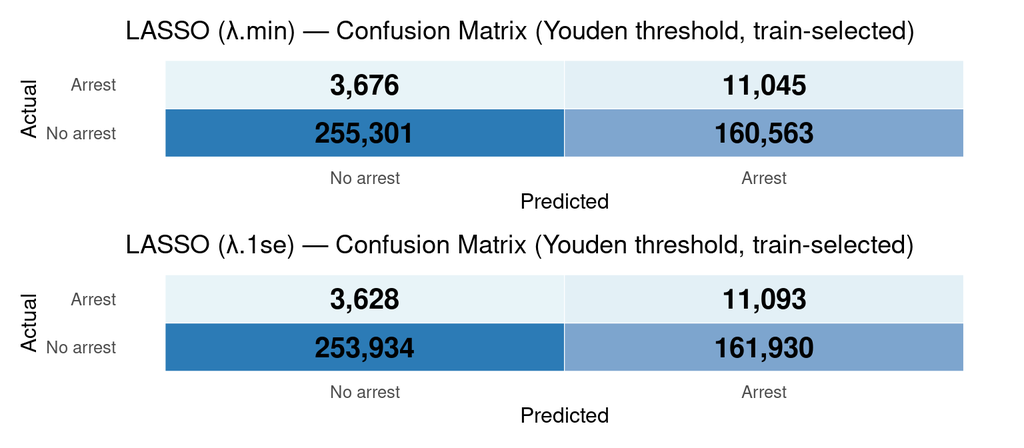

```r
p_cm_min <- plot_cm(y_test, class_lasso_min, "LASSO (λ.min) — Confusion Matrix (Youden threshold, train-selected)")
p_cm_1se <- plot_cm(y_test, class_lasso_1se, "LASSO (λ.1se) — Confusion Matrix (Youden threshold, train-selected)")

p_cm_min / p_cm_1se
```

```r
cat(sprintf(
  "λ.min — AUC: %.4f  |  Threshold (Youden, train-selected): %.4f  |  Sens: %.3f  |  Spec: %.3f  |  Bal.Acc: %.3f\n",
  auc_lasso_min, thr_lasso_min,
  met_lasso_min$sensitivity, met_lasso_min$specificity, met_lasso_min$balanced_acc
))
```

```
## λ.min — AUC: 0.7351  |  Threshold (Youden, train-selected): 0.0295  |  Sens: 0.750  |  Spec: 0.614  |  Bal.Acc: 0.682
```

```r
cat(sprintf(
  "λ.1se — AUC: %.4f  |  Threshold (Youden, train-selected): %.4f  |  Sens: %.3f  |  Spec: %.3f  |  Bal.Acc: %.3f\n",
  auc_lasso_1se, thr_lasso_1se,
  met_lasso_1se$sensitivity, met_lasso_1se$specificity, met_lasso_1se$balanced_acc
))
```

```
## λ.1se — AUC: 0.7340  |  Threshold (Youden, train-selected): 0.0296  |  Sens: 0.754  |  Spec: 0.611  |  Bal.Acc: 0.682
```

The test-set confusion matrices contain the following counts:

| Metric | $\lambda_{\min}$ | $\lambda_{1se}$ | Interpretation |
| --- | --- | --- | --- |
| True positives | 11,045 | 11,093 | Actual arrests correctly predicted as Arrest |
| False negatives | 3,676 | 3,628 | Actual arrests incorrectly predicted as No arrest |
| True negatives | 255,301 | 253,934 | Actual non-arrests correctly predicted as No arrest |
| False positives | 160,563 | 161,930 | Actual non-arrests incorrectly predicted as Arrest |

The two LASSO specifications show almost identical discrimination on the held-out test set:

$$AUC_{\min}=0.7351,\qquad
AUC_{1se}=0.7340$$

The small difference $\Delta AUC=0.0011$ confirms that the **stronger regularisation** of $\lambda_{1se}$produces almost no loss in out-of-sample discrimination. Test AUC is moderately lower than the cross-validated values ($0.7524$ and $0.7515$), suggesting a small decline in generalisation performance.

At the training-selected thresholds, which are then applied unchanged to the test set, the models exhibit a small sensitivity-specificity trade-off:

- The $\lambda_{\min}$ model achieves **75.0% sensitivity and 61.4% specificity**;
- The $\lambda_{1se}$ model increases sensitivity slightly to **75.4%**, while specificity falls slightly to **61.1%**.

In absolute terms, $\lambda_{1se}$ correctly detects **48 additional arrests**, but generates **1,367 additional false positives**. The large number of false positives is partly a consequence of the strong class imbalance: only $3.42\%$ of test observations are arrests.

Both models have balanced accuracy of approximately **0.682**, so these differences are small in practical terms.

### 5.4.2) Performance Analysis

This was partly covered in the previous section, so here we will be focusing on the metrics that we have yet to mention.

```r
bind_rows(
  compute_metrics(y_test, prob_lasso_min, thr_lasso_min, "LASSO λ.min"),
  compute_metrics(y_test, prob_lasso_1se, thr_lasso_1se, "LASSO λ.1se")
) %>%
  kbl(
    caption = "LASSO — full evaluation metrics (test set; Youden threshold selected on training set)",
    col.names = c(
      "Model","AUC","PR-AUC","Log-Loss","Brier", "Threshold","Sensitivity",
      "Specificity","Precision","F1","MCC","Bal. Acc."
    )
  ) %>%
  kable_styling(
    bootstrap_options = c("striped","condensed"),
    full_width = TRUE
  )
```

LASSO — full evaluation metrics (test set; Youden threshold selected on training set)

| Model | AUC | PR-AUC | Log-Loss | Brier | Threshold | Sensitivity | Specificity | Precision | F1 | MCC | Bal. Acc. |
| --- | --- | --- | --- | --- | --- | --- | --- | --- | --- | --- | --- |
| LASSO λ.min | 0.7351 | 0.0773 | 0.1373 | 0.0322 | 0.0295 | 0.750 | 0.614 | 0.064 | 0.119 | 0.135 | 0.682 |
| LASSO λ.1se | 0.7340 | 0.0763 | 0.1374 | 0.0322 | 0.0296 | 0.754 | 0.611 | 0.064 | 0.118 | 0.135 | 0.682 |

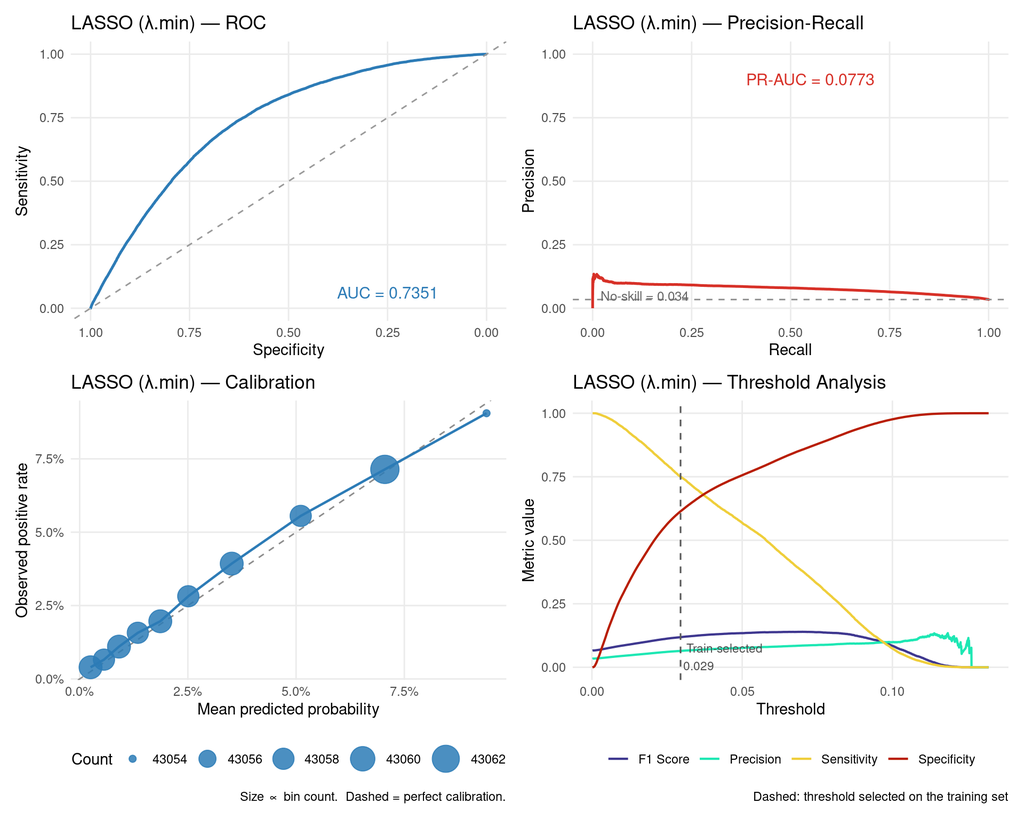

```r
eval_quad_plot(y_test, prob_lasso_min, thr_lasso_min, "LASSO (λ.min)")
```

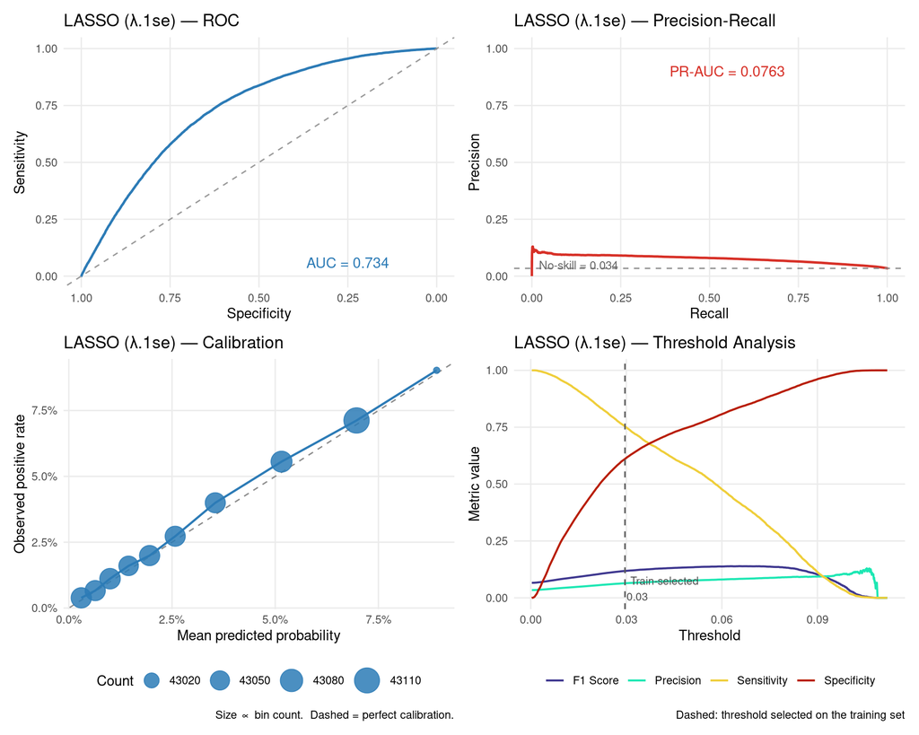

```r
eval_quad_plot(y_test, prob_lasso_1se, thr_lasso_1se, "LASSO (λ.1se)")
```

#### 5.4.2.1) Overall performance

| Metric | $\lambda_{\min}$ | $\lambda_{1se}$ | Interpretation |
| --- | --- | --- | --- |
| **AUC** | **0.7351** | 0.7340 | Virtually identical, moderate discrimination |
| **PR-AUC** | **0.0773** | 0.0763 | Similar rare-class ranking performance |
| **Log-Loss** | **0.1373** | 0.1374 | Essentially identical probability performance |
| **Brier** | 0.0322 | 0.0322 | Identical probability accuracy |
| **Threshold** | 0.0295 | 0.0296 | Low cutoffs, selected on the training set via Youden’s criterion and then applied unchanged to the test set |
| **Sensitivity** | 0.750 | **0.754** | $\lambda_{1se}$ detects slightly more actual arrests |
| **Specificity** | **0.614** | 0.611 | $\lambda_{\min}$ rejects slightly more non-arrests correctly |
| **Precision** | **0.064** | 0.064 | Low for both models |
| **F1** | **0.119** | 0.118 | Similar; limited by low precision |
| **MCC** | 0.135 | 0.135 | Weak positive association for both models |
| **Balanced Accuracy** | **0.682** | 0.682 | Essentially identical |

The main conclusion is that **the two LASSO models have almost indistinguishable predictive performance on the held-out test set**. The principal difference is small: $\lambda_{1se}$ identifies slightly more arrests, while $\lambda_{\min}$ correctly rejects slightly more non-arrests.

Since the 1-SE model achieves essentially the same discrimination with **50 rather than 63 non-zero coefficients**, it remains attractive from the perspective of parsimony. However, the choice also depends on whether false positives or false negatives are considered more costly.

#### 5.4.2.2) AUC

The test-set AUCs are:

$$\text{AUC}_{\min}=0.7351 \,\, \text{vs}
\,\, \text{AUC}_{1se}=0.7340 \rightarrow |\Delta_{AUC}| =
0.0011$$

An AUC of approximately $0.735$ means that, if we randomly select one observation where an arrest occurred and one where no arrest occurred, the model assigns a higher predicted probability to the arrest observation approximately **73.5% of the time**.

> **Note:** AUC measures **discrimination/ranking ability** across all possible classification thresholds. It does not mean that 73.5% of individual predictions are correct.

It is also useful to compare these results with cross-validation:

$$\begin{aligned}
\lambda_{\min}:&\quad
0.7524_{\text{CV}}\rightarrow0.7351_{\text{test}},\\
\lambda_{1se}:&\quad
0.7515_{\text{CV}}\rightarrow0.7340_{\text{test}}
\end{aligned}$$

There is therefore a modest reduction in discrimination on unseen data, but the test-set AUC remains reasonably close to the CV estimate. More importantly, **the relative performance of the two regularisation choices remains unchanged**.

Overall, the model exhibits **moderate out-of-sample discrimination**.

#### 5.4.2.3) PR-AUC

PR-AUC is particularly important because the test set is strongly imbalanced:

$$P(Y=1)\approx0.034$$

The two models achieve:

$$\text{PR-AUC}_{\min}=0.0773
\qquad\text{vs}\qquad
\text{PR-AUC}_{1se}=0.0763$$

Again, there is almost no difference.

However, the absolute value needs to be interpreted relative to the **no-skill baseline**.

This means that the model extracts meaningful information about the rare positive class, but at the same time $\text{PR-AUC}\approx0.077$ remains low in absolute terms.

So what we can say is that **the model ranks arrests reasonably well, but distinguishing a very rare positive class with high precision remains difficult.**

#### 5.4.2.4) Log-Loss

> Log-loss evaluates the **quality of the predicted probabilities** and penalises predictions that assign low probability to outcomes that actually occur.

The two models obtain:

$$\text{LogLoss}_{\min}=0.1373 \,\,
\text{vs} \,\, \text{LogLoss}_{1se}=0.1374 \rightarrow
|\Delta_{\text{LogLoss}}| = 0.0001$$

So, **no meaningful difference in probabilistic performance** between the two LASSO specifications according to this metric.

Unlike the confusion matrix, log-loss does not depend on the classification threshold. This further supports the conclusion that the underlying probability predictions produced by the two models are extremely similar.

#### 5.4.2.5) Brier Score and Calibration

The Brier score measures squared error between predicted probabilities and observed outcomes:

$$BS=\frac{1}{n}\sum_{i=1}^{n}(p_i-y_i)^2$$

where lower values are preferable.

Both models obtain:

$$\text{Brier}=0.0322$$

Thus, according to the Brier score, the two models have **identical probability-prediction accuracy**. But, because the outcome is rare, the raw value should again be compared with a simple baseline.

A model predicting the test-set prevalence, $p\approx0.034$, for every observation would have approximately: $\text{Brier}_{\text{baseline}} = p(1-p) = 0.034(0.966) \approx0.0330$. The LASSO score of $0.0322$ is better, although the improvement is relatively modest.

The calibration plots provide additional information. For both models, the observed positive rates lie generally close to the dashed perfect-calibration line over most probability bins, although some deviations are visible and neither model should be considered perfectly calibrated.

> In other words, the predicted probabilities appear **reasonably calibrated**: groups of observations assigned similar predicted arrest probabilities tend to exhibit observed arrest rates of approximately the same magnitude.

This highlights an important distinction:

$$\boxed{\text{Calibration} \neq
\text{Discrimination}}$$

A model can provide reasonably calibrated probabilities while still having only moderate ability to separate arrests from non-arrests. That appears to be the case here.

#### 5.4.2.6) Sensitivity and Specificity

At the training-selected thresholds, which are then applied unchanged to the test set, the models achieve:

$$\begin{aligned}
Sensitivity_{\min}&=0.750 & Specificity_{\min}&=0.614,\\
Sensitivity_{1se}&=0.754 & Specificity_{1se}&=0.611 \\
|\Delta_{Sensitivity}|&= 0.004 & |\Delta_{Specificity}|&=
0.003
\end{aligned}$$

Thus,

- $\lambda_{1se}$
  - It orrectly detects a larger proportion of actual arrests $75.0\% \rightarrow 75.4\%$. Alternatively, we can say that its miss rate decreases from $25.0\% \rightarrow 24.6\%$
  - However, this comes at the cost of specificity $61.4\% \rightarrow 61.1\%$.

Let us look at the corresponding false-alarm rates

$$38.6\% \quad \text{and}
\quad38.9\%$$

Therefore, $\lambda_{1se}$ achieves higher sensitivity but higher false-alarm rate, while $\lambda_{\min}$ is more conservative.

This is exactly the trade-off visible in the confusion matrices.

#### 5.4.2.7) Precision and F1

Precision is:

$$Precision_{\min}=0.064
\qquad\text{vs}\qquad
Precision_{1se}=0.064$$

This means that, only about **6–7% of observations classified as arrests are actual arrests**.

This is the main limitation of the thresholded classifier.

However, precision must be interpreted relative to the test-set prevalence $P(Y=1)=3.42\%$. For both models, we have that observations classified as arrests contain roughly $\frac{6.4\%}{3.42\%} \approx 1.9 \times$ **times the arrest prevalence of the overall test population**.

So, even though the **classifiers show improvement, the absolute precision remains low** due to the rarity of `arrested = 1`.

The corresponding F1 scores are:

$$F1_{\min}=0.119 \qquad \text{vs} \qquad
F1_{1se}=0.118$$

Since $F1= 2 \frac{Precision \cdot Recall} {Precision+Recall}$, the **low F1 is largely driven by the imbalance between high recall and low precision**.

#### 5.4.2.8) Thresholds

Using Youden’s criterion, the (train) selected thresholds are:

$$t_{\min}=0.0295 \qquad \text{vs} \qquad
t_{1se}=0.0296$$

Each threshold is selected once by maximising Youden’s $J$ on the corresponding lambda’s training-set ROC curve, then frozen and applied unchanged to the test set, so no test-set information is used in choosing the cutoff.

These values are much lower than the conventional threshold of $0.5$, but this is normal given that only approximately **3.4% of observations correspond to arrests**. The low cutoffs favor sensitivity and inevitably generate many false positives (see the Confusion Matrix for the trade-off).

#### 5.4.2.9) Balanced Accuracy

Balanced accuracy is:

$$BA=\frac{Sensitivity+Specificity}{2}$$

This metric is more informative than ordinary accuracy under severe class imbalance because it gives equal weight to performance on arrests and non-arrests.

The results are:

$$BA_{\min}=0.682 \qquad \text{vs} \qquad
BA_{1se}=0.682$$

So both models achieve approximately **68% average class-specific accuracy**.

Once again, there is no difference between the two models, but the important distinction is how that balanced accuracy is obtained:

- The 1-SE is more oriented toward detecting arrests,
- On the other hand, $\lambda_{\min}$ is better at identifying non-arrests.

#### 5.4.2.10) MCC

The **Matthews Correlation Coefficient (MCC)** is particularly useful for imbalanced classification because it incorporates all four components of the confusion matrix:

$$MCC = \frac{TP\cdot TN-FP\cdot
FN}{\sqrt{(TP+FP)(TP+FN)(TN+FP)(TN+FN)}} \in [-1, 1]$$
Where,

- $1$ = perfect prediction
- $0$ = no better than random association
- $-1$ = completely incorrect prediction

The MCC values are approximately $0.135$ for both models.

Thus, there is a **positive but weak association between predictions and actual outcomes**. Simply put:

- The model is doing meaningfully better than random classification and better than 2-Wheels-based models;
- But that its classification performance is limited.

#### 5.4.2.11) Final Remarks

Putting the diagnostics together:

- **Discrimination —** $AUC\approx0.735$: The models demonstrate **moderate ability to distinguish arrests from non-arrests**. Test discrimination is somewhat below the CV estimate of approximately $0.752$, but remains reasonably consistent out of sample.
- **Rare-class ranking —** $PR\text{-}AUC\approx0.077$: Performance is substantially above the no-skill baseline of approximately $0.034$, indicating meaningful signal for the rare positive class. Nevertheless, absolute precision-recall performance remains limited.
- **Probability prediction —** $Brier=0.0322,\ LogLoss\approx0.137$: The two models are essentially identical. Calibration plots additionally suggest that predicted probabilities are reasonably aligned with observed arrest frequencies.
- **Positive-class detection —** $Sensitivity\approx0.74-0.76$: The models identify a substantial majority of actual arrests.
- **False alarms —** $FPR=0.386$ and $0.389$: This sensitivity comes at the cost of incorrectly flagging a substantial proportion of actual non-arrests.
- **Precision —** $\approx0.064$ for both models: Only about 6.4% of predicted arrests correspond to actual arrests, reflecting the severe class imbalance and the sensitivity-oriented operating point.
- **Class balance —** $BA\approx0.682$: Both models perform meaningfully above chance when sensitivity and specificity receive equal weight, with virtually identical balanced accuracy.

Now for the final conclusions:

- The LASSO models demonstrate **moderate out-of-sample discrimination**, with test AUC around $0.735$, and contain meaningful predictive information about the rare arrest outcome, as demonstrated by a PR-AUC more than twice the no-skill baseline.
- However, the severe class imbalance remains a major limitation for hard classification. At the selected thresholds, the models recover approximately **75.0–75.4% of actual arrests**, but this comes at the cost of a **38.6–38.9% false-alarm rate** and precision of only approximately **6.4%**. Thus, the model has is better at being **risk-probability model than as a high-precision binary classifier** at the selected operating point.
- Furthermore, the two models are almost indistinguishable across AUC, PR-AUC, log-loss, Brier score, F1 and balanced accuracy. Given that we have 13 coefficients set to 0 with $\lambda_{1se}$ and almost no deterioration in predictive power, the results seem to indicate that we might be better off by choosing the **more parsimonious** $\lambda_{1se}$.